# Texas 2022 Analysis

Kirsten Sheehy

2024-05-16

## Packages to Load

```r
library(dplyr)
library(readr)
library(tidyr)
library(tibble)
library(lubridate)
library(tidyverse)
library(ggplot2)
library(lme4)
library(pscl)
library(MASS)
library(lmtest)
library(here)
library(knitr)
```

## Raw Data

```r
parasite_data <- read.csv(here("data", "copy_RAW_parasite_data_20230428.csv"))
length_data <- read.csv(here("data", "copy_Fish Length Data.csv"))
boris_data <- read.csv(here("data", "copy_RAW_Texas_BORISdata_20240515.csv"))
ID_data <- read.csv(here("data", "copy_RAW_trial_ID_data_completeonly_20240220.csv"))
```

## Tidy Data

### Parasite Data

```r
# rename columns to be consistent across data sets
parasite_data <- parasite_data %>% dplyr::rename(
  fish.ID = fish.id,
  site.ID = collection.site
)

# change collection.date and dissection.date to a date format (YYYY-MM-DD)
parasite_data$collection.date <- as.Date(parasite_data$collection.date,
  format = "%m/%d/%y"
)
parasite_data$dissection.date <- as.Date(parasite_data$dissection.date,
  format = "%m/%d/%y"
)

# change site names from abbreviation (WES, BR) to full (Weslaco, Brownsville)
parasite_data$site.ID <- gsub("WES", "Weslaco", parasite_data$site.ID)
parasite_data$site.ID <- gsub("BR-OP", "Brownsville", parasite_data$site.ID)

# note: the 'OP' in Brownsville stands for 'overpass'. We explored several sites
# in Brownsville, but only used the ones from the overpass for this study, so I
# simplified the name to just 'Brownsville'.
```

### Length Data

NOTE: I need to go back and check Tommy’s labeling and a few measurements to be sure they’re accurate.

```r
# rename columns to be consistent across data sets
length_data <- length_data %>% dplyr::rename(
  file.name = file_name,
  date.image = date_image,
  site.ID = site_ID,
  fish.ID = fish_ID
)

# remove spaces in fish.IDs
length_data$fish.ID <- gsub(" ", "", length_data$fish.ID)
```

### Boris Data

```r
# remove unnecessary columns (largely meta data and unused features in BORIS)
boris_data <- boris_data %>% dplyr::select(
  -Observation.date, # this is just the day processed in BORIS
  -Description,
  -FPS,
  -Behavioral.category,
  -Modifiers,
  -Comment.start,
  -Comment.stop
)

# rename columns (to match up across data)
boris_data <- boris_data %>% dplyr::rename(
  pool = Subject,
  trial.length = Total.length,
  start = Start..s.,
  stop = Stop..s.,
  duration = Duration..s.
)

# split Media.file into columns to extract file name (could also use
# Observation.id, but figured this would help avoid typos made in Boris)
boris_data <- boris_data %>% tidyr::separate_wider_delim(Media.file,
  delim = "/",
  names = c(
    "file1",
    "file2",
    "file3",
    "file4",
    "file5",
    "video.ID"
  ),
  too_few = "align_end"
)

# remove the excess filepath columns
boris_data <- boris_data %>% dplyr::select(
  -file1,
  -file2,
  -file3,
  -file4,
  -file5
)

# video.id (from the file path split above) is the file name of the recording.
# It decomposes into the site ID, trial number, batch, and date recorded. The
# following code duplicates the column, then splits the information in video.id
# into separate columns.
boris_data$video.ID.split <- boris_data$video.ID
boris_data <- boris_data %>% tidyr::separate_wider_delim(video.ID.split,
  delim = "_",
  names = c(
    "site.ID",
    "trial.ID",
    "batch.ID",
    "trial.date"
  )
)

# remove the file type from the trial.date column
boris_data$trial.date <- gsub(".mov", "", boris_data$trial.date)

# change trial.date from (YYYYMMDD) to a date (YYYY-MM-DD)
boris_data$trial.date <- as.Date(boris_data$trial.date, format = "%Y%m%d")

# remove 'trial' from the data entries for trial.ID
boris_data$trial.ID <- gsub("trial", "", boris_data$trial.ID)
boris_data$trial.ID <- gsub("trail", "", boris_data$trial.ID) # had to find a few where this was a typo in the file name

# remove 'pool' from data in pool column
boris_data$pool <- gsub("Pool ", "", boris_data$pool)

# change site ID from abbreviations to full name
# note: doing them in this order is important
boris_data$site.ID <- gsub("Wes", "Weslaco", boris_data$site.ID)
boris_data$site.ID <- gsub("WES", "Weslaco", boris_data$site.ID)
boris_data$site.ID <- gsub("BR1", "Brownsville", boris_data$site.ID)
boris_data$site.ID <- gsub("BR2", "Brownsville", boris_data$site.ID)
boris_data$site.ID <- gsub("BR", "Brownsville", boris_data$site.ID)
# note: there are three entry types for Brownsville: BR, BR1, and BR2
# need to revisit lab notebook to confirm, but I believe BR1 and BR2
# are the two sides of the garage (i.e. the two cameras)
```

Now that the columns are all formatted correctly, I need to pull out the behaviors from the Behavior column into their own, separate columns.

```r
# start by duplicating the 'Behavior' column twice. This will be used to extract start and stop times of the three behaviors (open, hiding, startle).
boris_data <- boris_data %>%
  dplyr::mutate(behavior.start = Behavior)

boris_data <- boris_data %>%
  dplyr::mutate(behavior.stop = Behavior)

# then pivot_wider with names from behavior.start and values from start
boris_data_wide <- boris_data %>%
  tidyr::pivot_wider(
    names_from = behavior.start,
    values_from = start,
    names_prefix = "start."
  )

# do the same with stop
boris_data_wide <- boris_data_wide %>%
  tidyr::pivot_wider(
    names_from = behavior.stop,
    values_from = stop,
    names_prefix = "stop."
  )

# now, I need to get the duration of each behavior using the start and stop times
boris_data_wide <- boris_data_wide %>%
  tidyr::pivot_wider(
    names_from = Behavior,
    values_from = duration,
    names_prefix = "duration."
  )

# I'll remove stop_Startle and duration_Startle because these are 'points' not 'states' and do not have a duration
boris_data_wide <- boris_data_wide %>% dplyr::select(
  -stop.Startle,
  -duration.Startle
)
```

Now, I need to join the ID_data and boris_data_wide datasets.

```r
# I need a column in both ID_data and boris_data_wide to join by
# I'll create a new column that merges the file name (which already includes
# site, trial, and batch) with pool # for both data sets

boris_data_wide$merge.ID <- paste(
  boris_data_wide$video.ID,
  boris_data_wide$pool
)

ID_data$merge.ID <- paste(
  ID_data$video.ID,
  ID_data$pool
)

boris_data_merge <- boris_data_wide %>%
  left_join(ID_data, by = "merge.ID")
```

Now we tidy the merged data.

```r
# remove duplicate columns
boris_data_merge <- boris_data_merge %>% dplyr::select(
  -merge.ID,
  -video.ID.y,
  -pool.y,
  -site.ID.y,
  -trial.ID.y,
  -batch.ID.y,
  -trial.date.y
)

# rename columns to get rid of .x and .y appendages
boris_data_merge <- boris_data_merge %>% dplyr::rename(
  video.ID = video.ID.x,
  pool = pool.x,
  site.ID = site.ID.x,
  trial.ID = trial.ID.x,
  batch.ID = batch.ID.x,
  trial.date = trial.date.x
)

# add column for species from fish.ID
boris_data_merge <- boris_data_merge %>%
  mutate(species = fish.ID)

boris_data_merge <- boris_data_merge %>%
  separate_wider_delim(species,
    delim = "-",
    names = c(
      "species",
      "junk.num"
    )
  )

boris_data_merge <- boris_data_merge %>% dplyr::select(-junk.num)

# filling the 'start.startle' column based on fish and trial ID
boris_data_merge <- boris_data_merge %>%
  group_by(fish.ID, trial.ID) %>%
  fill(start.Startle, .direction = "downup")
```

```r
# new columns with the earliest open and hiding value per fish per trial
boris_data_merge <- boris_data_merge %>%
  group_by(fish.ID, trial.ID) %>%
  mutate(
    earliest.open = min(start.Open, na.rm = TRUE),
    earliest.hiding = min(start.Hiding, na.rm = TRUE)
  )
# creates a trial cutoff time by taking the earliest behavior time (either open or closed)
# and adding 1200 seconds (20 minutes) to it
boris_data_merge <- boris_data_merge %>%
  group_by(fish.ID, trial.ID) %>%
  mutate(
    trial.end = pmin(earliest.open, earliest.hiding, na.rm = TRUE) + 1200
  )

# now, I need to remove all observations per fish per trial that exceed this cutoff time
boris_data_cutoff <- boris_data_merge %>%
  group_by(fish.ID, trial.ID) %>%
  filter(start.Open <= trial.end |
    start.Hiding <= trial.end)

# now, I need to create an 'end cap' value to replace any 'stop' behaviors
# basically, I need to close the observation (like in Boris)
# this also means I'll need to change the 'duration' columns, which are automatically
# exported from Boris.

# replace stop.Open with trial cutoff if higher than cutoff
boris_data_cutoff <- boris_data_cutoff %>%
  group_by(fish.ID, trial.ID) %>%
  mutate(stop.Open = if_else(stop.Open > trial.end, trial.end, stop.Open))

# replace stop.Open with trial cutoff if higher than cutoff
boris_data_cutoff <- boris_data_cutoff %>%
  group_by(fish.ID, trial.ID) %>%
  mutate(stop.Hiding = if_else(stop.Hiding > trial.end, trial.end, stop.Hiding))

# now, recalculate duration based on new end times
boris_data_cutoff <- boris_data_cutoff %>%
  group_by(fish.ID, trial.ID) %>%
  mutate(duration.Open = stop.Open - start.Open)

boris_data_cutoff <- boris_data_cutoff %>%
  group_by(fish.ID, trial.ID) %>%
  mutate(duration.Hiding = stop.Hiding - start.Hiding)
```

```r
# removing 3rd trial since most fish didn't get three
boris_data_cutoff <- boris_data_cutoff %>%
  filter(trial.ID == "1" |
    trial.ID == "2")
```

Now let’s create some columns for summary data (e.g. total time hiding)

```r
# time hiding per trial
total_hiding <- boris_data_cutoff %>%
  aggregate(
    duration.Hiding ~ fish.ID + trial.ID,
    sum
  )

total_hiding <- total_hiding %>%
  mutate(duplicate.fish.ID = fish.ID)

total_hiding <- total_hiding %>%
  separate_wider_delim(duplicate.fish.ID,
    delim = "-",
    names = c(
      "species",
      "junk.num"
    )
  )

total_hiding <- total_hiding %>%
  dplyr::select(-junk.num)

# time in open per trial
total_open <- boris_data_cutoff %>%
  aggregate(
    duration.Open ~ fish.ID + trial.ID,
    sum
  )

total_open <- total_open %>%
  mutate(duplicate.fish.ID = fish.ID)

total_open <- total_open %>%
  separate_wider_delim(duplicate.fish.ID,
    delim = "-",
    names = c(
      "species",
      "junk.num"
    )
  )

total_open <- total_open %>%
  dplyr::select(-junk.num)
```

Now, I want to merge total hiding and open per fish per trial.

```r
# I'm going to create a column with both fish ID and trial to create a unique
# row for each fish/trial combination. I'll then use this to join the hiding
# and open datasets
total_open <- total_open %>%
  unite(fish.ID.trial, c(fish.ID, trial.ID))

total_hiding <- total_hiding %>%
  unite(fish.ID.trial, c(fish.ID, trial.ID))

# merge
total_hide_open <- total_hiding %>%
  left_join(total_open, by = "fish.ID.trial")

# get rid of duplicate columns
total_hide_open <- total_hide_open %>%
  dplyr::select(-species.y)

# separate fish ID and trial
total_hide_open <- total_hide_open %>%
  separate_wider_delim(fish.ID.trial,
    delim = "_",
    names = c(
      "fish.ID",
      "trial"
    )
  )

# and for my own sanity, renaming the species column
total_hide_open <- total_hide_open %>%
  rename(species = species.x)

# time hiding and open by trial
total_hide_open <- total_hide_open %>%
  mutate(site.ID = boris_data_cutoff$site.ID[match(fish.ID, boris_data_cutoff$fish.ID)])

# hiding and open by trial, joined with parasite and size data
total_hide_open <- total_hide_open %>%
  left_join(parasite_data, by = "fish.ID")
total_hide_open <- total_hide_open %>%
  left_join(length_data, by = "fish.ID")
total_hide_open <- total_hide_open %>%
  dplyr::select(
    -site.ID.y,
    -species.y,
    -site.ID,
    -species
  )

# rename columns
total_hide_open <- total_hide_open %>% rename(
  species = species.x,
  site.ID = site.ID.x,
  total.parasites = totalpara
)
```

## Inspect data

First, some ‘dummy checks’ to make sure the data make sense

```r
# fish.IDs
unique(ID_data$fish.ID) # 68 unique IDs
```

```
##  [1] "PF-08BR" "PL-25"   "PF-25B"  "PF-26"   "PF-27"   "PF-28"   "PF-30"
##  [8] "PF-31"   "PF-32"   "PF-33"   "PF-35"   "PF-36"   "PF-37"   "PF-38"
## [15] "PF-39"   "PF-40"   "PF-46"   "PF-60"   "PF-61"   "PF-62"   "PF-65"
## [22] "PL-02"   "PL-05"   "PL-07"   "PL-08"   "PL-09"   "PL-11"   "PL-12"
## [29] "PL-13"   "PL-15"   "PL-20"   "PL-21"   "PL-22"   "PL-26"   "PL-28"
## [36] "PL-30"   "PL-31"   "PL-32"   "PL-34"   "PL-35"   "PL-37"   "PL-38"
## [43] "PL-39"   "PL-41"   "PL-43"   "PL-44"   "PL-45"   "PL-46"   "PL-47"
## [50] "PL-48"   "PL-49"   "PL-50"   "PL-51"   "PL-52"   "PL-53"   "PL-54"
## [57] "PL-55"   "PL-56"   "PL-57"   "PL-58"   "PL-59"   "PL-60"   "PL-61"
## [64] "PL-62"   "PL-63"   "PL-64"   "PL-65"   "PL-66"
```

```r
unique(boris_data_cutoff$fish.ID) # 69 unique IDs -> somehow an NA was introduced?
```

```
##  [1] "PF-31"   "PL-61"   "PL-46"   "PF-61"   "PF-26"   "PL-57"   NA
##  [8] "PL-65"   "PL-52"   "PL-53"   "PL-15"   "PL-64"   "PL-49"   "PF-65"
## [15] "PL-58"   "PL-50"   "PF-27"   "PL-12"   "PL-43"   "PL-45"   "PF-33"
## [22] "PF-35"   "PL-63"   "PL-21"   "PL-38"   "PF-62"   "PL-44"   "PF-25B"
## [29] "PL-05"   "PL-08"   "PL-55"   "PL-07"   "PF-30"   "PL-54"   "PL-13"
## [36] "PL-47"   "PF-60"   "PL-25"   "PL-28"   "PL-60"   "PL-09"   "PL-20"
## [43] "PL-22"   "PL-66"   "PL-26"   "PF-46"   "PL-56"   "PF-32"   "PL-59"
## [50] "PL-51"   "PF-08BR" "PL-41"   "PL-34"   "PL-62"   "PF-28"   "PL-48"
## [57] "PL-11"   "PF-39"   "PL-30"   "PL-02"   "PL-35"   "PL-39"   "PL-37"
## [64] "PF-36"   "PF-38"   "PL-31"   "PL-32"   "PF-40"   "PF-37"
```

```r
unique(parasite_data$fish.ID)
```

```
##   [1] "P.formosa"   "P.latipinna" "PF-01"       "PF-02"       "PF-04"
##   [6] "PF-05"       "PF-07"       "PF-08"       "PF-09"       "PF-10"
##  [11] "PF-11"       "PF-12"       "PF-13"       "PF-14"       "PF-15"
##  [16] "PF-16"       "PF-17"       "PF-18"       "PF-19"       "PF-20"
##  [21] "PF-21"       "PF-22"       "PF-23"       "PF-24"       "PF-25B"
##  [26] "PF-26"       "PF-27"       "PF-28"       "PF-29"       "PF-3"
##  [31] "PF-30"       "PF-31"       "PF-32"       "PF-33"       "PF-34"
##  [36] "PF-35"       "PF-36"       "PF-37"       "PF-38"       "PF-39"
##  [41] "PF-40"       "PF-41"       "PF-42"       "PF-43"       "PF-44"
##  [46] "PF-45"       "PF-46"       "PF-47"       "PF-49"       "PF-50"
##  [51] "PF-51"       "PF-52"       "PF-53"       "PF-54"       "PF-55"
##  [56] "PF-56"       "PF-57"       "PF-58"       "PF-59"       "PF-6"
##  [61] "PF-60"       "PF-61"       "PF-62"       "PF-63"       "PF-64"
##  [66] "PF-65"       "PL-01"       "PL-02"       "PL-04"       "PL-05"
##  [71] "PL-07"       "PL-08"       "PL-09"       "PL-10"       "PL-11"
##  [76] "PL-12"       "PL-13"       "PL-14"       "PL-15"       "PL-16"
##  [81] "PL-17"       "PL-18"       "PL-19"       "PL-20"       "PL-22"
##  [86] "PL-25"       "PL-26"       "PL-27"       "PL-28"       "PL-29"
##  [91] "PL-30"       "PL-31"       "PL-32"       "PL-34"       "PL-35"
##  [96] "PL-36"       "PL-37"       "PL-38"       "PL-40"       "PL-41"
## [101] "PL-42"       "PL-43"       "PL-44"       "PL-46"       "PL-47"
## [106] "PL-48"       "PL-49"       "PL-50"       "PL-51"       "PL-52"
## [111] "PL-53"       "PL-54"       "PL-55"       "PL-56"       "PL-57"
## [116] "PL-58"       "PL-60"       "PL-62"       "PL-63"       "PL-64"
## [121] "PL-66"
```

```r
# 121, but 2 are just 'P.formosa' and 'P.latipina' because these are how fish were labeled if they didn't receive trials or if their IDs were unreadable on the labels
```

This all makes sense. The number of unique fish IDs from my notebook match up with the boris data. There are more parasite fish IDs because we sent them fish that didn’t necessarily go through trials, in addition to trial fish.

```r
# video.ID
unique(boris_data_wide$video.ID) # 36
```

```
##  [1] "WES_trial1_03_20220808.mov" "WES_trial2_02_20220812.mov"
##  [3] "WES_trial1_05_20220812.mov" "WES_trial2_01_20220812.mov"
##  [5] "WES_trial1_04_20220812.mov" "BR_trial1_02_20220808.mov"
##  [7] "WES_trial1_03_20220812.mov" "WES_trial3_02_20220809.mov"
##  [9] "WES_trial2_03_20220812.mov" "BR_trial3_02_20220808.mov"
## [11] "WES_trial2_03_20220808.mov" "WES_trial1_02_20220812.mov"
## [13] "WES_trial1_02_20220808.mov" "BR_trial2_02_20220809.mov"
## [15] "BR_trial2_02_20220808.mov"  "BR1_trial2_01_20220810.mov"
## [17] "BR2_trial2_01_20220810.mov" "WES_trial2_02_20220808.mov"
## [19] "WES_trial2_01_20220808.mov" "BR_trial2_01_20220808.mov"
## [21] "BR_trial1_01_20220808.mov"  "WES_trial2_04_20220812.mov"
## [23] "WES_trial1_01_20220808.mov" "BR_trial3_01_20220808.mov"
## [25] "WES_trial2_05_20220812.mov" "WES_trial3_01_20220809.mov"
## [27] "BR1_trial3_01_20220810.mov" "BR2_trial3_01_20220810.mov"
## [29] "BR1_trial3_02_20220810.mov" "BR2_trial3_02_20220810.mov"
## [31] "BR1_trial1_02_20220810.mov" "BR2_trial2_02_20220810.mov"
## [33] "Wes_trial1_01_20220812.mov" "BR2_trial1_02_20220810.mov"
## [35] "BR1_trial1_01_20220810.mov" "BR1_trial2_02_20220810.mov"
```

```r
unique(ID_data$video.ID) # 36
```

```
##  [1] "BR_trial1_01_20220808.mov"  "BR_trial3_01_20220808.mov"
##  [3] "BR_trial2_01_20220808.mov"  "WES_trial1_01_20220808.mov"
##  [5] "WES_trial2_01_20220808.mov" "WES_trial3_02_20220809.mov"
##  [7] "WES_trial1_02_20220808.mov" "WES_trial2_02_20220808.mov"
##  [9] "WES_trial1_03_20220808.mov" "WES_trial2_03_20220808.mov"
## [11] "WES_trial3_01_20220809.mov" "BR1_trial1_01_20220810.mov"
## [13] "BR1_trial2_01_20220810.mov" "BR2_trial1_01_20220810.mov"
## [15] "BR2_trial2_01_20220810.mov" "BR2_trial1_02_20220810.mov"
## [17] "BR2_trial2_02_20220810.mov" "BR2_trial3_02_20220810.mov"
## [19] "BR2_trial3_01_20220810.mov" "BR1_trial3_01_20220810.mov"
## [21] "BR1_trial1_02_20220810.mov" "BR1_trial2_02_20220810.mov"
## [23] "WES_trial1_04_20220812.mov" "WES_trial2_04_20220812.mov"
## [25] "WES_trial1_05_20220812.mov" "WES_trial2_05_20220812.mov"
## [27] "BR_trial1_02_20220808.mov"  "BR_trial2_02_20220808.mov"
## [29] "BR_trial3_02_20220808.mov"  "BR1_trial3_02_20220810.mov"
## [31] "WES_trial1_02_20220812.mov" "WES_trial2_02_20220812.mov"
## [33] "WES_trial1_03_20220812.mov" "WES_trial2_03_20220812.mov"
## [35] "Wes_trial1_01_20220812.mov" "WES_trial2_01_20220812.mov"
```

This also makes sense. We have the same number of video IDs in the boris and ID data.

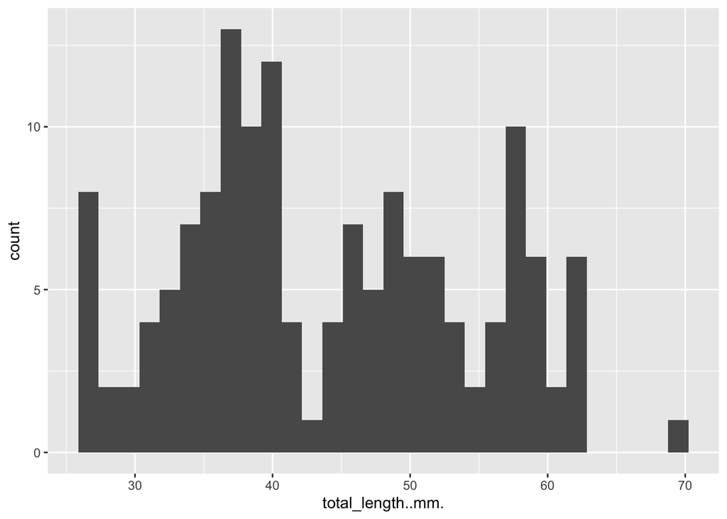

```r
# length data
length_hist <- total_hide_open %>%
  ggplot(mapping = aes(total_length..mm.)) +
  geom_histogram()
length_hist
```

Seems like a fairly normal distribution for length? possibly bimodal?

Let’s take a look at the parasite data.

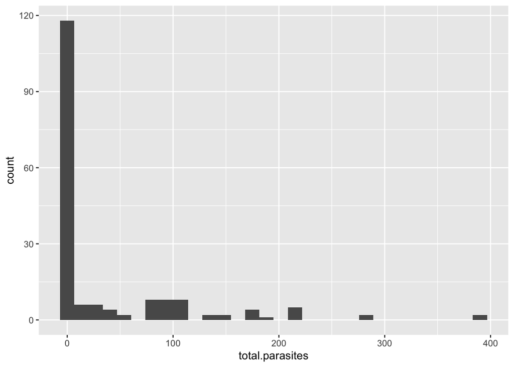

```r
# parasite data
parasite_hist <- total_hide_open %>%
  ggplot(mapping = aes(total.parasites)) +
  geom_histogram()
parasite_hist
```

Not a normal distribution. No obvious pattern here, besides a lot of zeros. Should check to see how this matches up with notes in the parasite data about specimen quality).

Let’s look at the parasites by species and site.

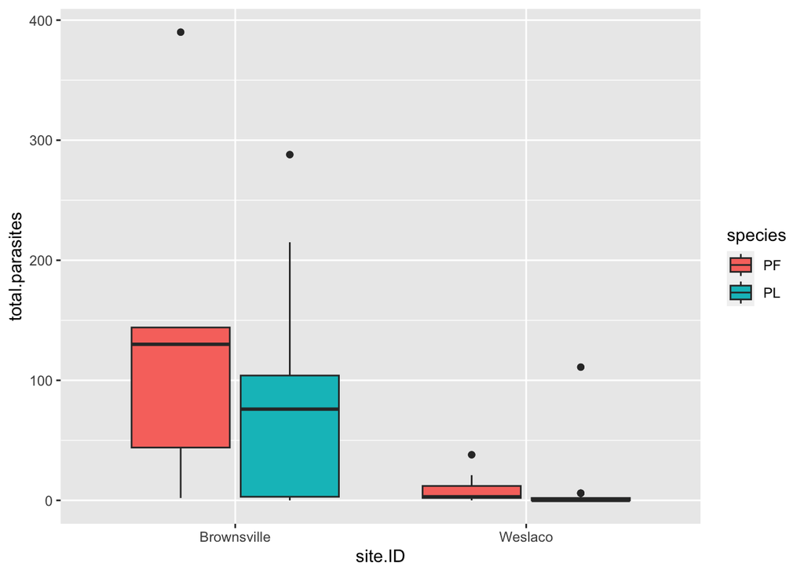

```r
sp_parasite_box <- total_hide_open %>%
  ggplot(mapping = aes(
    fill = species,
    x = site.ID,
    y = total.parasites
  )) +
  geom_boxplot()
sp_parasite_box
```

Ok, so there is a clear pattern of way more parasites in Brownsville, generally. It also seems like there may be more parasites on amazons in both sites, but we’ll see what the stats say.

Now, let’s take a look at the shape of the behavior data.

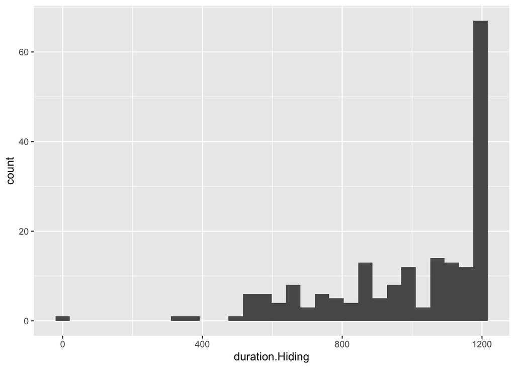

```r
# boris_data, distributions
hiding_hist <- total_hide_open %>%
  ggplot(mapping = aes(duration.Hiding)) +
  geom_histogram()
hiding_hist
```

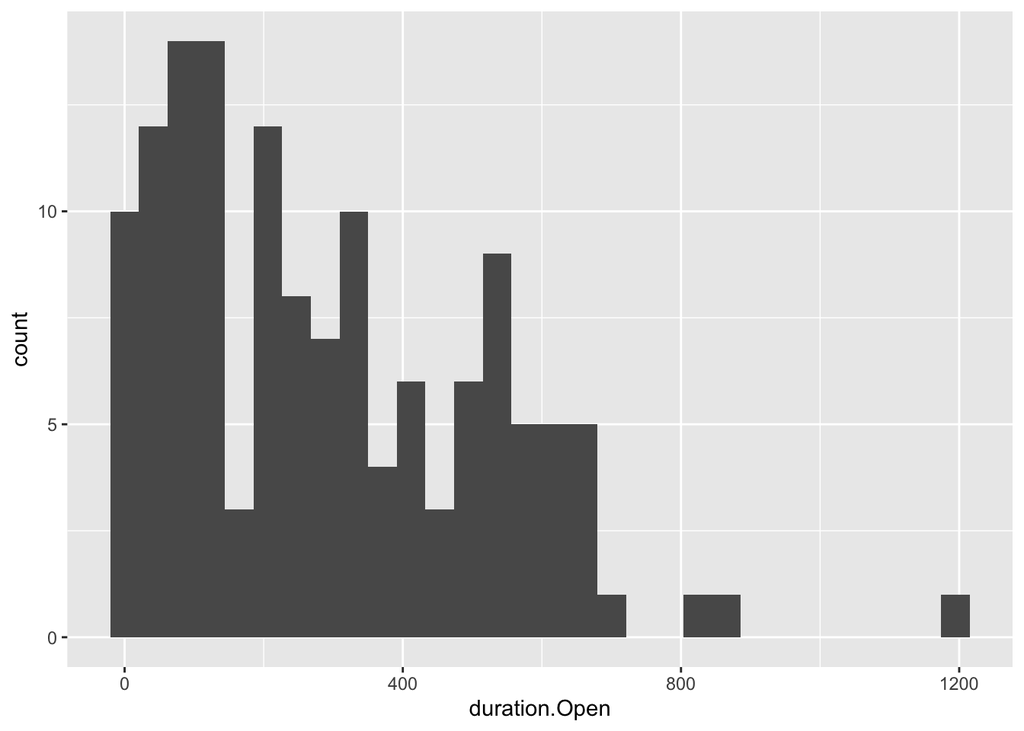

```r
open_hist <- total_hide_open %>%
  ggplot(mapping = aes(duration.Open)) +
  geom_histogram()
open_hist
```

Now, let’s take a look at the open vs. hiding data by species.

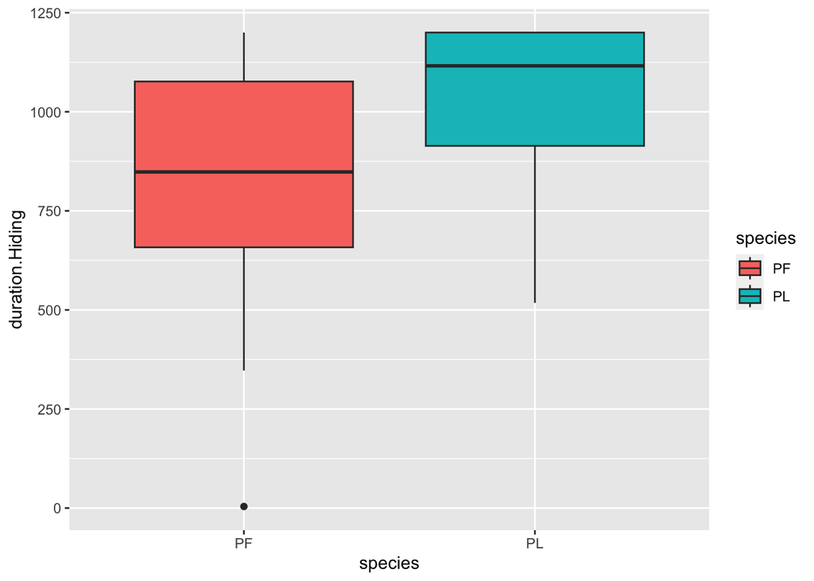

```r
# diff in hiding between species
species_hiding <- total_hide_open %>%
  ggplot(mapping = aes(
    x = species,
    y = duration.Hiding,
    fill = species
  )) +
  geom_boxplot()
species_hiding
```

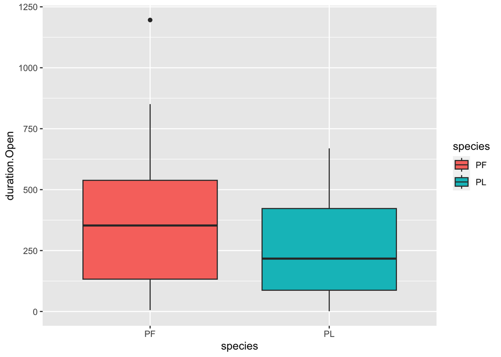

```r
# diff in open between species
species_open <- total_hide_open %>%
  ggplot(mapping = aes(
    x = species,
    y = duration.Open,
    fill = species
  )) +
  geom_boxplot()
species_open
```

Again, we’ll see how the stats pan out, but it looks like Amazons might spend less time hiding and more time in the open than sailfins.